# Name: Chenghao Ding

### Date: 8/27/2023

# Introduction

The purpose of this project is to gauge your technical skills and problem solving ability by working through something similar to a real NBA data science project. You will work your way through this jupyter notebook, answering questions as you go along. Please begin by adding your name to the top markdown chunk in this document. When you're finished with the document, come back and type your answers into the answer key at the top. Please leave all your work below and have your answers where indicated below as well. Please note that we will be reviewing your code so make it clear, concise and avoid long printouts. Feel free to add in as many new code chunks as you'd like.

Remember that we will be grading the quality of your code and visuals alongside the correctness of your answers. Please try to use packages like pandas/numpy and matplotlib/seaborn as much as possible (instead of base python data manipulations and explicit loops.)

**WARNING:** Your project will **ONLY** be graded if it's knit to an HTML document where we can see your code. Be careful to make sure that any long lines of code appropriately visibly wrap around visibly to the next line, as code that's cut off from the side of the document cannot be graded.

**Note:**

**Throughout this document, any `season` column represents the year each season started. For example, the 2015-16 season will be in the dataset as 2015. For most of the rest of the project, we will refer to a season by just this number (e.g. 2015) instead of the full text (e.g. 2015-16).**

# Answers

## Part 1

**Question 1:**

- 1st Team: 22.7 points per game
- 2nd Team: 20.2 points per game
- 3rd Team: 18.1 points per game
- All-Star: 19.4 points per game

**Question 2:** 3.7 Years

**Question 3:**

- Elite: 3 players.
- All-Star: 1 players.
- Starter: 9 players.
- Rotation: 7 players.
- Roster: 10 players.
- Out of League: 43 players.

**Open Ended Modeling Question:** Please show your work and leave all responses below in the document.

## Part 2

**Question 1:** 29.7%  
**Question 2:** Written question, put answer below in the document.  
**Question 3:** Written question, put answer below in the document.

# Setup and Data

```python
import pandas as pd
# Note you will likely have to change these paths.
# If your data is in the same folder as this project,
# the paths will likely be fixed for you by deleting ../../Data/awards_project/ from each string.
awards = pd.read_csv("awards_data.csv")
player_data = pd.read_csv("player_stats.csv")
team_data = pd.read_csv("team_stats.csv")
rebounding_data = pd.read_csv("team_rebounding_data_22.csv")
```

## Part 1 -- Awards

In this section, you're going to work with data relating to player awards and statistics. You'll start with some data manipulation questions and work towards building a model to predict broad levels of career success.

### Question 1

**QUESTION:** What is the average number of points per game for players in the 2007-2021 seasons who won All NBA First, Second, and Third teams (**not** the All Defensive Teams), as well as for players who were in the All-Star Game (**not** the rookie all-star game)?

```python
def calculate_team_ppg(data, team_column):
    selected_players = data[data[team_column] == 1]
    merged_df = player_data.merge(selected_players, on='nbapersonid')
    total_points = merged_df['points'].sum()
    total_games = merged_df['games'].sum()
    return total_points / total_games

# Calculate PPG for All NBA First, Second, Third and All-Star Team
allnba1_ppg = calculate_team_ppg(awards, 'All NBA First Team')
allnba2_ppg = calculate_team_ppg(awards, 'All NBA Second Team')
allnba3_ppg = calculate_team_ppg(awards, 'All NBA Third Team')
allS_ppg = calculate_team_ppg(awards, 'all_star_game')
```

**ANSWER 1:**

1st Team: 22.7 points per game  
2nd Team: 20.2 points per game  
3rd Team: 18.1 points per game  
All-Star: 19.4 points per game

### Question 2

**QUESTION:** What was the average number of years of experience in the league it takes for players to make their first All NBA Selection (1st, 2nd, or 3rd team)? Please limit your sample to players drafted in 2007 or later who did eventually go on to win at least one All NBA selection. For example:

- Luka Doncic is in the dataset as 2 years. He was drafted in 2018 and won his first All NBA award in 2019 (which was his second season).
- LeBron James is not in this dataset, as he was drafted prior to 2007.
- Lu Dort is not in this dataset, as he has not received any All NBA honors.

```python
df_players = awards[(awards['All NBA First Team'] == 1) | (awards['All NBA Second Team'] == 1) | (awards['All NBA Third Team'] == 1)]
min_season = df_players.groupby('nbapersonid')['season'].idxmin()
merged_df = player_data.merge(df_players.loc[min_season], on=['nbapersonid', 'season'])
df_players_2007 = merged_df[merged_df['draftyear'] >= 2007]

avg_yrs = (df_players_2007['season'] - df_players_2007['draftyear']).mean()
```

**ANSWER 2:**

3.7 Years

## Data Cleaning Interlude

You're going to work to create a dataset with a "career outcome" for each player, representing the highest level of success that the player achieved for **at least two** seasons *after his first four seasons in the league* (examples to follow below!). To do this, you'll start with single season level outcomes. On a single season level, the outcomes are:

- Elite: A player is "Elite" in a season if he won any All NBA award (1st, 2nd, or 3rd team), MVP, or DPOY in that season.
- All-Star: A player is "All-Star" in a season if he was selected to be an All-Star that season.
- Starter: A player is a "Starter" in a season if he started in at least 41 games in the season OR if he played at least 2000 minutes in the season.
- Rotation: A player is a "Rotation" player in a season if he played at least 1000 minutes in the season.
- Roster: A player is a "Roster" player in a season if he played at least 1 minute for an NBA team but did not meet any of the above criteria.
- Out of the League: A player is "Out of the League" if he is not in the NBA in that season.

We need to make an adjustment for determining Starter/Rotation qualifications for a few seasons that didn't have 82 games per team. Assume that there were 66 possible games in the 2011 lockout season and 72 possible games in each of the 2019 and 2020 seasons that were shortened due to covid. Specifically, if a player played 900 minutes in 2011, he **would** meet the rotation criteria because his final minutes would be considered to be 900 *(82/66) = 1118. Please use this math for both minutes and games started, so a player who started 38 games in 2019 or 2020 would be considered to have started 38* (82/72) = 43 games, and thus would qualify for starting 41. Any answers should be calculated assuming you round the multiplied values to the nearest whole number.

Note that on a season level, a player's outcome is the highest level of success he qualifies for in that season. Thus, since Shai Gilgeous-Alexander was both All-NBA 1st team and an All-Star last year, he would be considered to be "Elite" for the 2022 season, but would still qualify for a career outcome of All-Star if in the rest of his career he made one more All-Star game but no more All-NBA teams. Note this is a hypothetical, and Shai has not yet played enough to have a career outcome.

Examples:

- A player who enters the league as a rookie and has season outcomes of Roster (1), Rotation (2), Rotation (3), Roster (4), Roster (5), Out of the League (6+) would be considered "Out of the League," because after his first four seasons, he only has a single Roster year, which does not qualify him for any success outcome.
- A player who enters the league as a rookie and has season outcomes of Roster (1), Rotation (2), Starter (3), Starter (4), Starter (5), Starter (6), All-Star (7), Elite (8), Starter (9) would be considered "All-Star," because he had at least two seasons after his first four at all-star level of production or higher.
- A player who enters the league as a rookie and has season outcomes of Roster (1), Rotation (2), Starter (3), Starter (4), Starter (5), Starter (6), Rotation (7), Rotation (8), Roster (9) would be considered a "Starter" because he has two seasons after his first four at a starter level of production.

### Question 3

**QUESTION:** There are 73 players in the `player_data` dataset who have 2010 listed as their draft year. How many of those players have a **career** outcome in each of the 6 buckets?

```python
df_player = player_data.iloc[:, 0:10]
df_player.loc[df_player['season'] == 2011, ['games_start', 'mins']] *=  82/66
df_player.loc[df_player['season'].isin([2019, 2020]), ['games_start', 'mins']] *= 82/72

# some players can play on multiple teams in the same season, so aggregate them
df_grouped = df_player.groupby(['nbapersonid', 'player', 'draftyear', 'season'])[['games',
                              'games_start','mins']].sum().reset_index()
df_awards = awards[['nbapersonid', 'season', 'All NBA First Team', 'All NBA Second Team', 'All NBA Third Team',
                    'Most Valuable Player_rk', 'Defensive Player Of The Year_rk','all_star_game']]
merged_df = df_grouped.merge(df_awards, how='left', on=['nbapersonid', 'season'])

# evaluate single season level outcomes for each player by definition above
merged_df['Elite'] = (merged_df['All NBA First Team'] == 1) | (merged_df['All NBA Second Team'] == 1) | \
(merged_df['All NBA Third Team'] == 1) | (merged_df['Most Valuable Player_rk'].notna() == True) | \
(merged_df['Defensive Player Of The Year_rk'].notna() == True)

merged_df['All-Star'] = (merged_df['all_star_game'] == True)
merged_df['Starter'] = (round(merged_df['games_start']) >= 41) | (round(merged_df['mins'])>=2000)
merged_df['Rotation'] = (round(merged_df['mins'])>=1000)
merged_df['Roster'] = (round(merged_df['mins'])>=1)
merged_df['Out of the League'] = (round(merged_df['mins'])==0)

res_grouped = merged_df.groupby('nbapersonid')

# Create a dictionary to store career outcomes
career_outcomes = {}

for player_id, group_data in res_grouped:
    if len(group_data)>=6:
        # Select the data after 4 years' in each player's data
        df = group_data.iloc[4:]
        outcome_levels = ['Elite', 'All-Star', 'Starter', 'Rotation', 'Roster', 'Out of the League']
        career_outcome = None

        for level in outcome_levels:
            if (df[level] == True).sum()>= 2:
                career_outcome = level
                break

        career_outcomes[player_id] = career_outcome
    else:
        career_outcomes[player_id] = 'Out of the League'

player_2010 = player_data[player_data['draftyear'] == 2010]['nbapersonid'].unique()

# Initialize counters for each outcome
category_count = {category: 0 for category in set(career_outcomes.values())}

for key, value in career_outcomes.items():
    if key in player_2010:
        category_count[value] += 1
```

### **ANSWER 3:**

Elite: 3 players.  
All-Star: 1 players.  
Starter: 9 players.  
Rotation: 7 players.  
Roster: 10 players.  
Out of League: 43 players.

### Open Ended Modeling Question

In this question, you will work to build a model to predict a player's career outcome based on information up through the first four years of his career.

This question is intentionally left fairly open ended, but here are some notes and specifications.

1. We know modeling questions can take a long time, and that qualified candidates will have different levels of experience with "formal" modeling. Don't be discouraged. It's not our intention to make you spend excessive time here. If you get your model to a good spot but think you could do better by spending a lot more time, you can just write a bit about your ideas for future improvement and leave it there. Further, we're more interested in your thought process and critical thinking than we are in specific modeling techniques. Using smart features is more important than using fancy mathematical machinery, and a successful candidate could use a simple regression approach.
2. You may use any data provided in this project, but please do not bring in any external sources of data. Note that while most of the data provided goes back to 2007, All NBA and All Rookie team voting is only included back to 2011.
3. A player needs to complete three additional seasons after their first four to be considered as having a distinct career outcome for our dataset. Because the dataset in this project ends in 2021, this means that a player would need to have had the chance to play in the '21, '20, and '19 seasons after his first four years, and thus his first four years would have been '18, '17, '16, and '15. **For this reason, limit your training data to players who were drafted in or before the 2015 season.** Karl-Anthony Towns was the #1 pick in that season.
4. Once you build your model, predict on all players who were drafted in 2018-2021 (They have between 1 and 4 seasons of data available and have not yet started accumulating seasons that inform their career outcome).
5. You can predict a single career outcome for each player, but it's better if you can predict the probability that each player falls into each outcome bucket.
6. Include, as part of your answer:
   - A brief written overview of how your model works, targeted towards a decision maker in the front office without a strong statistical background.
   - What you view as the strengths and weaknesses of your model.
   - How you'd address the weaknesses if you had more time and or more data.
   - A matplotlib or plotly visualization highlighting some part of your modeling process, the model itself, or your results.
   - Your predictions for Shai Gilgeous-Alexander, Zion Williamson, James Wiseman, and Josh Giddey.
   - (Bonus!) An html table (for example, see the package `reactable`) containing all predictions for the players drafted in 2019-2021.

### The strengths and weaknesses of your model:

The PCA analysis greatly reduced features' dimension, and make features independent as much as possible. For such features like 'nbapersonid', 'player' which are clearly not helpful in prediction are neglected. Also, the model can predict the probability that each player falls into each outcome bucket.

However, this model largely depends on player data quality, if the data is noisy, incomplete, or biased, the model's performance may suffer. This model might not perform well on new, unseen data especially for players who are new to the league and are lack of data.

### How you'd address the weaknesses if you had more time and or more data.

I would try to add more weighting factors to most recent seasons' statistics to update their status, and if awards data is available for more players, that would be also helpful to spot the Elite players when they are relatively new in the league, such as all-star ranks.

```python
# Note: Here as well as anywhere else, feel free to add as many code chunks as you'd like.
import matplotlib.pyplot as plt

season_counts = player_data.groupby('nbapersonid')['season'].nunique()
# Get 'person_id' with more than 7 unique 'season' entries
selected_ids = season_counts[season_counts >= 7].index.tolist()
df_player = player_data[player_data['nbapersonid'].isin(selected_ids)]
```

```python
train = df_player[df_player['draftyear']<=2015]
target = train['nbapersonid'].map(career_outcomes)

columns_to_drop = ['draftpick', 'fgp', 'fgp3', 'fgp2' ,'ftp', 'nbapersonid', 'player', 'draftyear', 'season',
                   'nbateamid', 'team', 'games', 'fga', 'fga3', 'fga2', 'off_reb_pct', 'def_reb_pct'
                  ,'ast_pct', 'tot_reb_pct', 'stl_pct','blk_pct','tov_pct',
                   'OWS', 'DWS', 'OBPM','DBPM', 'fta', 'off_reb', 'def_reb', 'fgm']
train_dropped = train.drop(columns=columns_to_drop)
train_dropped.dropna(inplace=True)
target = target.loc[train_dropped.index]

test = player_data[player_data['draftyear'].isin([2018,2019,2020,2021])]
test_dropped = test.drop(columns=columns_to_drop)

player_index = test.iloc[:,:7]
test_dropped.dropna(inplace=True)
```

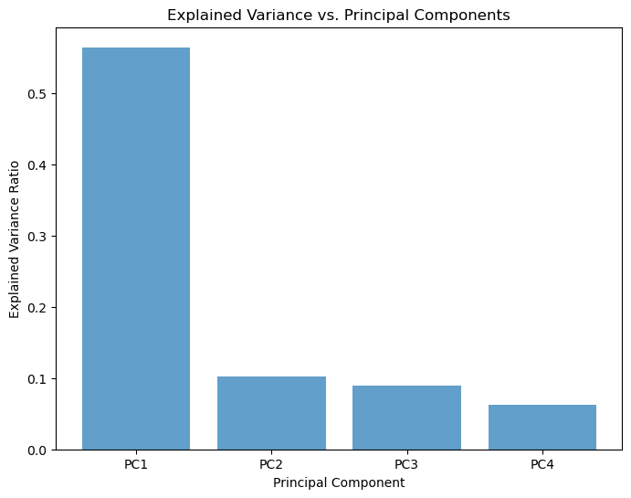

```python
from sklearn.preprocessing import StandardScaler
from sklearn.decomposition import PCA
from sklearn.linear_model import LogisticRegression

# Standardize the features
scaler = StandardScaler()
train_scaled = scaler.fit_transform(train_dropped)
test_scaled = scaler.transform(test_dropped)

# Create a PCA instance
pca = PCA(n_components=4)

# Fit and transform PCA on the scaled features
train_pca = pca.fit_transform(train_scaled)
test_pca = pca.transform(test_scaled)

# Explained variance ratios of the principal components
explained_variances = pca.explained_variance_ratio_

# Principal components
principal_components = pca.components_

plt.figure(figsize=(8, 6))
x_labels = [f'PC{i}' for i in range(1, len(explained_variances) + 1)]
plt.bar(x_labels, explained_variances, alpha=0.7, align='center')
plt.ylabel('Explained Variance Ratio')
plt.xlabel('Principal Component')
plt.title('Explained Variance vs. Principal Components')
plt.show()

# Create a LogisticRegression model
logreg = LogisticRegression()

# Train the model on the training data
logreg.fit(train_pca, target)

# Make predictions on the test data
outcome_pred = logreg.predict(test_pca)
test_dropped['career_outcome'] = outcome_pred
```

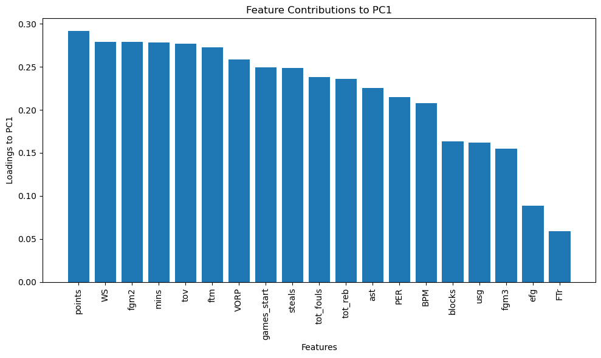

```python
# Extract the loadings for PC1
loadings_pc1 = pca.components_[0]
feature_names = train_dropped.columns

# Sort the loadings and their corresponding feature names
sorted_loadings_indices = loadings_pc1.argsort()[::-1]
sorted_loadings = loadings_pc1[sorted_loadings_indices]
sorted_feature_names = feature_names[sorted_loadings_indices]  # Replace with your feature names

# Create a bar plot of the feature contributions to PC1
plt.figure(figsize=(10, 6))
plt.bar(sorted_feature_names, sorted_loadings)
plt.xlabel('Features')
plt.ylabel('Loadings to PC1')
plt.title('Feature Contributions to PC1')
plt.xticks(rotation=90)
plt.tight_layout()
plt.show()
```

```python
merged_res = player_index.merge(test_dropped, left_index=True, right_index=True)

# predictions for Shai Gilgeous-Alexander, Zion Williamson, James Wiseman, Josh Giddey in single season level
df_res = merged_res[merged_res['player'].isin(['Shai Gilgeous-Alexander', 'Zion Williamson',
                                                'James Wiseman', 'Josh Giddey'])]
```

```python
# predict the probability that each player falls into each outcome bucket
predicted_probabilities = logreg.predict_proba(test_pca)
career_outcome_levels = logreg.classes_
```

```python
# Group by 'nbapersonid' and get the indices of most recent season
most_recent_indices = merged_res.groupby('nbapersonid')['season'].idxmax()
df_res = merged_res.loc[most_recent_indices]
df_res_2019 = df_res[df_res['draftyear'].isin([2019, 2020, 2021])][['player', 'career_outcome']]
```

```python
# a html table containing all predictions for the players drafted in 2019-2021
from itables import init_notebook_mode, show
init_notebook_mode(all_interactive=True)
show(df_res_2019)
```

[output not shown]

## Part 2 -- Predicting Team Stats

In this section, we're going to introduce a simple way to predict team offensive rebound percent in the next game and then discuss ways to improve those predictions.

### Question 1

Using the `rebounding_data` dataset, we'll predict a team's next game's offensive rebounding percent to be their average offensive rebounding percent in all prior games. On a single game level, offensive rebounding percent is the number of offensive rebounds divided by their number offensive rebound "chances" (essentially the team's missed shots). On a multi-game sample, it should be the total number of offensive rebounds divided by the total number of offensive rebound chances.

Please calculate what OKC's predicted offensive rebound percent is for game 81 in the data. That is, use games 1-80 to predict game 81.

```python
df_rebound = rebounding_data[ ((rebounding_data['team']== 'OKC') | (rebounding_data['opp_team']== 'OKC'))
                             & (rebounding_data['game_number'] < 81)]
df_rebound['oreb_pct'].mean()
```

```
0.2970536940853842
```

**ANSWER 1:**

29.7%

### Question 2

There are a few limitations to the method we used above. For example, if a team has a great offensive rebounder who has played in most games this season but will be out due to an injury for the next game, we might reasonably predict a lower team offensive rebound percent for the next game.

Please discuss how you would think about changing our original model to better account for missing players. You do not have to write any code or implement any changes, and you can assume you have access to any reasonable data that isn't provided in this project. Try to be clear and concise with your answer.

**ANSWER 2:**  
I would suggest keep track of the following statistics for each player in each season:

(1) Player value analysis:

Analyze the impact of the missing player on team performance. Look at historical games data to understand how the team performed when this player was absent, especially offensive rebounding numbers. For example, the team's historical performance in similar situations.

(2) Adjusting Weighting Factors:

Modify the weights and importance of offensive rebounds in the model based on the absence of the key player. For instance, we can increase the weight given to the player's historical offensive rebounding performance.

### Question 3

In question 2, you saw and discussed how to deal with one weakness of the model. For this question, please write about 1-3 other potential weaknesses of the simple average model you made in question 1 and discuss how you would deal with each of them. You may either explain a weakness and discuss how you'd fix that weakness, then move onto the next issue, or you can start by explaining multiple weaknesses with the original approach and discuss one overall modeling methodology you'd use that gets around most or all of them. Again, you do not need to write any code or implement any changes, and you can assume you have access to any reasonable data that isn't provided in this project. Try to be clear and concise with your answer.

**ANSWER 3:**

Weakness 1: The simple average model regard all the opponents as the same. However, some team are good at get the offensive rebounds, while others are not.

Solution: Doing more Opponent Analysis Study different opponent's strengths and weaknesses. If the opponent has a strong defensive rebounding performance, the impact of the missing offensive rebounder might be more serious. On the other hand, if the opponent struggles with defensive rebounding, the impact might be less.

Weakness 2: The simple average model didn't consider the aging factor of players. As their performance will generally decrease as they are older.

Solution: add Player aging factor to the current model Implement an aging factor for each player's historical data. Add weights to more recent games results when the player were injured in the team when we building the machine learning model.

Weakness 3: No replacement player performance analysis

Solution: Study the offensive rebounds performance for Player available for replacement. For exmaple, check the available replacement for injured players. Analyze their past performances and statistics related to offensive rebounding. Compare these metrics with the injured player's statistics to see how well they can fill the gap.